# DATA 608 – Knowledge and Visual Analytics: Assignment 1

Amber Ferger

9/6/2020

**Principles of Data Visualization and Introduction to ggplot2**

I have provided you with data about the 5,000 fastest growing companies in the US, as compiled by Inc. magazine. lets read this in:

```r
inc <- read.csv("https://raw.githubusercontent.com/charleyferrari/CUNY_DATA_608/master/module1/Data/inc5000_data.csv", header= TRUE)
```

And lets preview this data:

```r
head(inc)
```

[output not shown]

```r
summary(inc)
```

[output not shown]

Think a bit on what these summaries mean. Use the space below to add some more relevant non-visual exploratory information you think helps you understand this data:

| DISTINCT_INDUSTRIES |
| --- |
| 25 |

| Industry | NUM_COMPANIES | PCT_TOTAL_COMPANIES | INDUSTRY_REVENUE | INDUSTRY_EMPLOYEES |
| --- | --- | --- | --- | --- |
| Consumer Products & Services | 203 | 0.0405919 | 14956400000 | 45464 |
| Energy | 109 | 0.0217956 | 13771600000 | 26437 |
| Construction | 187 | 0.0373925 | 13174300000 | 29099 |
| Financial Services | 260 | 0.0519896 | 13150900000 | 47693 |
| Retail | 203 | 0.0405919 | 10257400000 | 37068 |
| Human Resources | 196 | 0.0391922 | 9246100000 | 226980 |
| Advertising & Marketing | 471 | 0.0941812 | 7785000000 | 39731 |
| Government Services | 202 | 0.0403919 | 6009100000 | 26185 |
| Security | 73 | 0.0145971 | 3812800000 | 41059 |
| Travel & Hospitality | 62 | 0.0123975 | 2931600000 | 23035 |

**Top States by Total Revenue:**

```r
sum2 <- inc %>%
  group_by(State) %>%
  summarize(TOTAL_COMPANIES = n(),
            TOTAL_REVENUE = sum(Revenue),
            TOTAL_EMPLOYEES = sum(Employees),
            AVERAGE_REVENUE = mean(Revenue),
            MEDIAN_REVENUE = median(Revenue),
            MIN_REVENUE = min(Revenue),
            MAX_REVENUE = max(Revenue))
# top 5 industries by avg rev
kable(
  sum2 %>%
  arrange(desc(TOTAL_REVENUE)) %>%
  top_n(.,5)
)
```

| State | TOTAL_COMPANIES | TOTAL_REVENUE | TOTAL_EMPLOYEES | AVERAGE_REVENUE | MEDIAN_REVENUE | MIN_REVENUE | MAX_REVENUE |
| --- | --- | --- | --- | --- | --- | --- | --- |
| IL | 273 | 33244300000 | NA | 121773993 | 14700000 | 2000000 | 1.01e+10 |
| NY | 311 | 18260400000 | 84370 | 58715113 | 8800000 | 2000000 | 4.60e+09 |
| NC | 137 | 9258500000 | NA | 67580292 | 12300000 | 2000000 | 3.50e+09 |
| WI | 79 | 7296600000 | NA | 92362025 | 10900000 | 2300000 | 4.70e+09 |
| ID | 17 | 3935900000 | 5817 | 231523529 | 8800000 | 2000000 | 2.80e+09 |
| IA | 28 | 3448000000 | 11344 | 123142857 | 14650000 | 2100000 | 2.80e+09 |

## Question 1

Create a graph that shows the distribution of companies in the dataset by State (ie how many are in each state). There are a lot of States, so consider which axis you should use. This visualization is ultimately going to be consumed on a ‘portrait’ oriented screen (ie taller than wide), which should further guide your layout choices.

```r
p <- ggplot(inc, aes(x=fct_rev(fct_infreq(State)))) +
  geom_histogram(stat="count") +
  ggtitle("Distribution of Top 5000 Companies by State") +
  xlab("State") + ylab("Number of Companies") +
  geom_bar(width=0.1) +
  coord_flip()
```

```
Ignoring unknown parameters: binwidth, bins, pad
```

[figure not shown]

```r
p
```

## Question 2

Lets dig in on the state with the 3rd most companies in the data set. Imagine you work for the state and are interested in how many people are employed by companies in different industries. Create a plot that shows the average and/or median employment by industry for companies in this state (only use cases with full data, use R’s `complete.cases()` function.) In addition to this, your graph should show how variable the ranges are, and you should deal with outliers.

**First, let’s subset our data to state with the 3rd most companies. We’ll also eliminate any records that have null values. We can see that the state we’re working with is NY:**

```r
thirdState <- inc %>%
  add_count(State) %>%
  arrange(desc(n)) %>%
  filter(State == unique(State)[3]) %>%
  select(-n)

thirdState <- thirdState[complete.cases(thirdState), ]

unique(thirdState$State)
```

```
[1] "NY"
```

**Next, let’s take a look at each Industry separately. This will help us to identify any outliers (dots above or below the body of the boxplot). We can see that many of the Industries have some outliers in the dataset.**

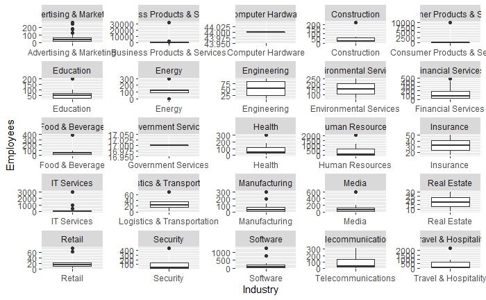

**Now we will define a function to remove the outliers from each Industry separately and apply it to our dataframe. We can confirm that our outliers are removed by checking the rowcounts of the original NY dataset to the new dataset.**

```r
removeOutliers <- function(df){
  outliers <- boxplot.stats(df$Employees)$out
  df <- df %>%
    filter(!Employees %in% outliers)
  return(df)
}

# group data into separate dataframes based on Industry
groupedData <- thirdState %>%
  group_by(Industry) %>%
  group_split()

# apply removeOutliers function to dataframe
finalData <- do.call("rbind", lapply(groupedData, removeOutliers))

paste0('Num rows in original dataset: ', nrow(thirdState), ' | Num rows in new dataset: ', nrow(finalData))
```

```
[1] "Num rows in original dataset: 311 | Num rows in new dataset: 280"
```

**Finally, we can create a plot that shows the average employment by industry:**

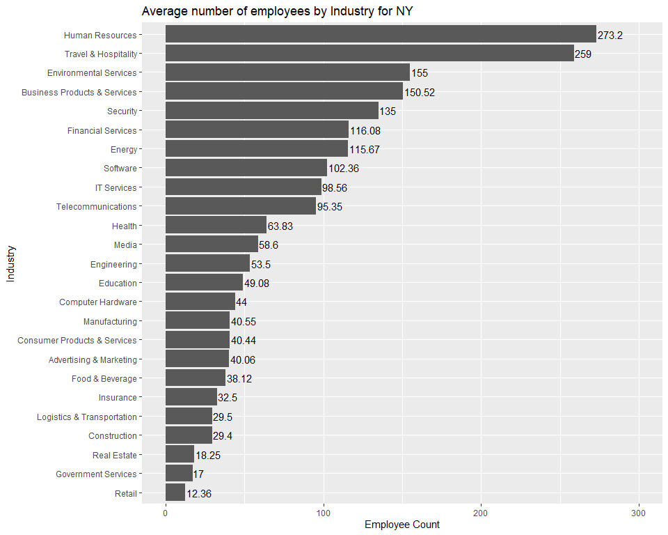

**And similarly, we can create a plot that shows the median employment by industry:**

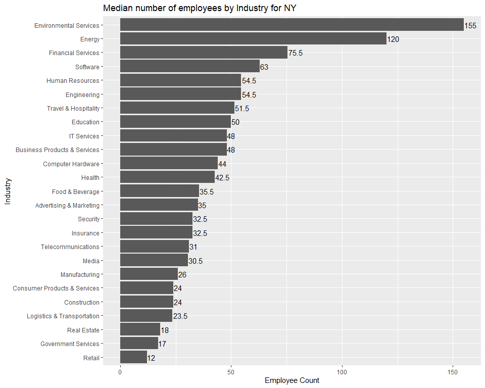

```r
ggplot(finalData, aes(x=reorder(Industry, Employees, median), y=Employees)) +
  stat_summary(fun="median", geom="bar") +
  ggtitle(paste0("Median number of employees by Industry for ",unique(finalData$State))) +
  xlab("Industry") + ylab("Employee Count") +
  coord_flip() +
  stat_summary(aes(label=round(..y..,2)), fun=median, geom="text", vjust = 0.5, hjust = -0.05)
```

## Question 3

Now imagine you work for an investor and want to see which industries generate the most revenue per employee. Create a chart that makes this information clear. Once again, the distribution per industry should be shown.

**First, we can group our data by Industry and calculate the revenue by employee:**

```r
revByEmployee <- inc %>%
  group_by(Industry) %>%
  summarize(TOTAL_REVENUE = sum(Revenue, na.rm=TRUE),
            TOTAL_EMPLOYEES = sum(Employees, na.rm = TRUE),
            REV_PER_EMPLOYEE = sum(Revenue, na.rm=TRUE)/ sum(Employees, na.rm = TRUE)) %>%
  arrange(desc(REV_PER_EMPLOYEE)) %>%
  ungroup()
revByEmployee
```

| Industry | TOTAL_REVENUE | TOTAL_EMPLOYEES | REV_PER_EMPLOYEE |
| --- | --- | --- | --- |
| Computer Hardware | 11885700000 | 9714 | 1223563.93 |
| Energy | 13771600000 | 26437 | 520921.44 |
| Construction | 13174300000 | 29099 | 452740.64 |
| Logistics & Transportation | 14840500000 | 39994 | 371068.16 |
| Consumer Products & Services | 14956400000 | 45464 | 328972.37 |
| Insurance | 2337900000 | 7339 | 318558.39 |
| Manufacturing | 12684000000 | 43942 | 288653.22 |
| Retail | 10257400000 | 37068 | 276718.46 |
| Financial Services | 13150900000 | 47693 | 275740.67 |
| Environmental Services | 2638800000 | 10155 | 259852.29 |

[output cut: 15 more lines]

**Now, we can plot this information:**

[figure not shown]